# R实战第二版笔记-中级绘图

Studennt. LI Junjie

Dongbei University of Finance & Economics

2020-06-21

# 1 加载经常用的R包

```r
library(pacman)
# 读数据
p_load(readxl,writexl,data.table,openxlsx,haven,rvest)
```

```r
# 数据探索
p_load(tidyverse,DT,skimr,DataExplorer,explore,vtable,stringr,kableExtra,lubridate)
```

```r
# 模型
p_load(grf,glmnet,caret,tidytext,fpp2,forecast,car,tseries,hdm,tidymodels,broom)
```

```r
# 可视化
p_load(patchwork,ggrepel,ggcorrplot,gghighlight,ggthemes,shiny)
```

```r
# 其它常用包
p_load(magrittr,listviewer,devtools,here,janitor,reticulate,jsonlite)
```

# 2 散点图

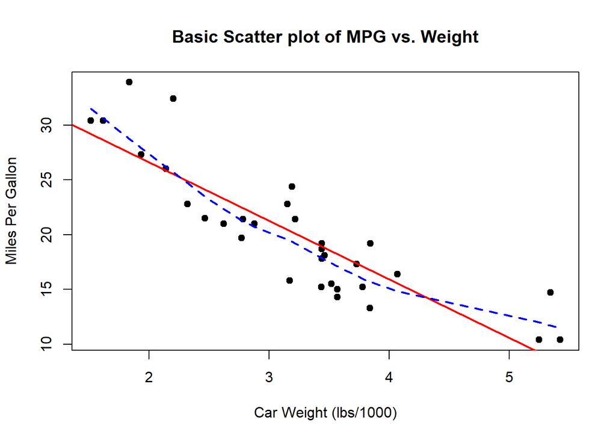

```r
plot(mtcars$wt,mtcars$mpg,
     main = "Basic Scatter plot of MPG vs. Weight",
     xlab = "Car Weight (lbs/1000)",
     ylab = "Miles Per Gallon",
     pch = 19)
abline(lm(mtcars$mpg~mtcars$wt), col="red", lwd=2, lty=1)
lines(lowess(mtcars$wt,mtcars$mpg), col="blue", lwd=2, lty=2)
```

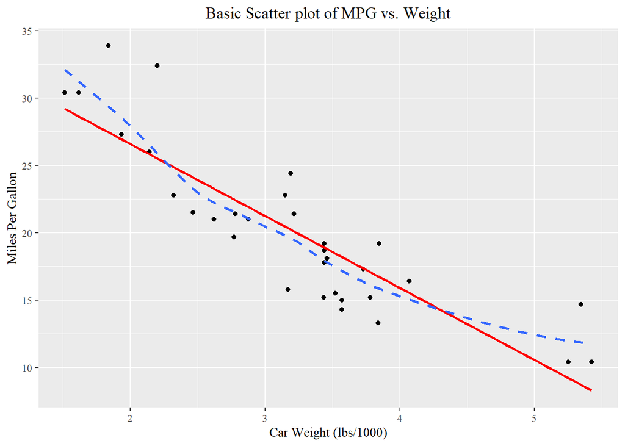

```r
mtcars %>%
  ggplot(aes(x = wt, y = mpg)) +
  geom_point() +
  geom_smooth(method = "lm", col = "red", se = FALSE,linetype = 1) +
  geom_smooth(data = mtcars,aes(x = wt, y = mpg),se = FALSE,linetype = 2) +
  labs(title = "Basic Scatter plot of MPG vs. Weight",
       x = "Car Weight (lbs/1000)",
       y = "Miles Per Gallon") +
  theme(text = element_text(family = enfont),
        plot.title = element_text(hjust = 0.5))
```

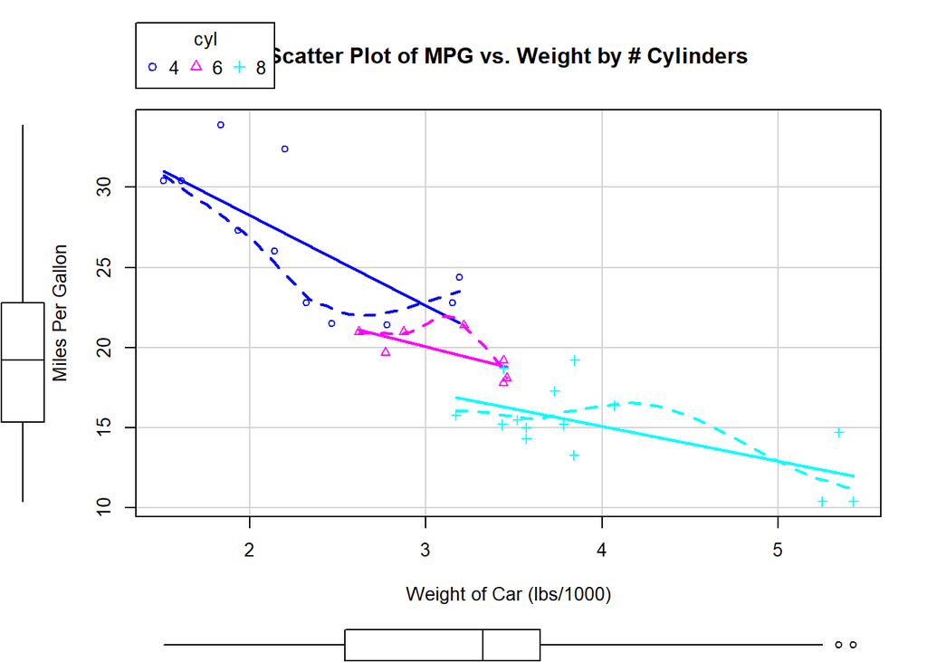

```r
library(car)
scatterplot(
  mpg ~ wt | cyl,
  data = mtcars,
  lwd = 2,
  main = "Scatter Plot of MPG vs. Weight by # Cylinders",
  xlab = "Weight of Car (lbs/1000)",
  ylab = "Miles Per Gallon",
  # id.method = "identify",
  # labels = row.names(mtcars),
  boxplots = "xy"
)
```

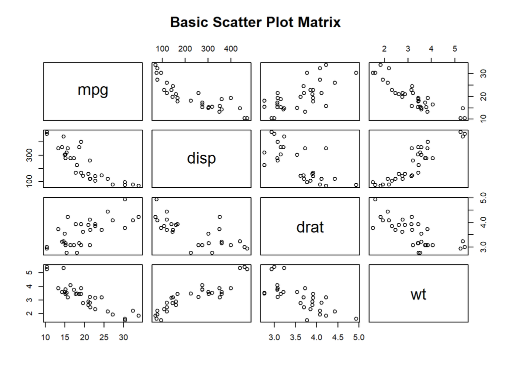

```r
pairs( ~ mpg + disp + drat + wt, data = mtcars,
       main = "Basic Scatter Plot Matrix")
```

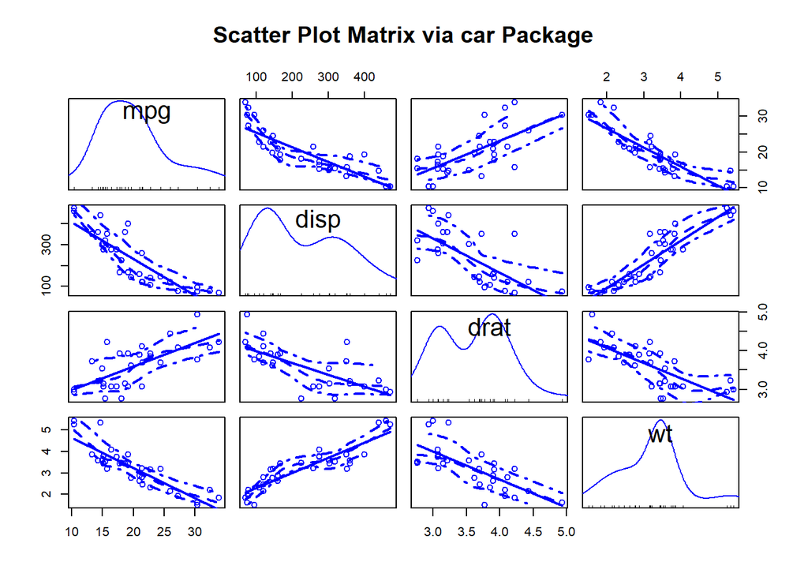

```r
library(car)
scatterplotMatrix(
  ~ mpg + disp + drat + wt,
  data = mtcars,
  main = "Scatter Plot Matrix via car Package"
)
```

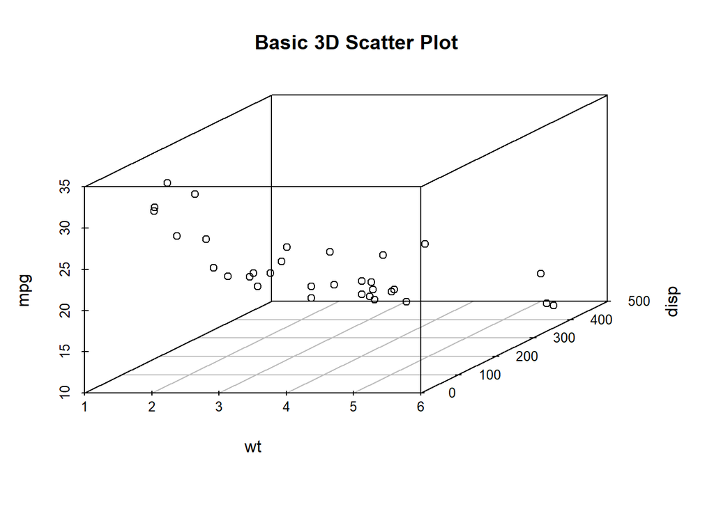

```r
p_load(scatterplot3d)
attach(mtcars)
scatterplot3d(wt, disp, mpg,main="Basic 3D Scatter Plot")
detach(mtcars)
```

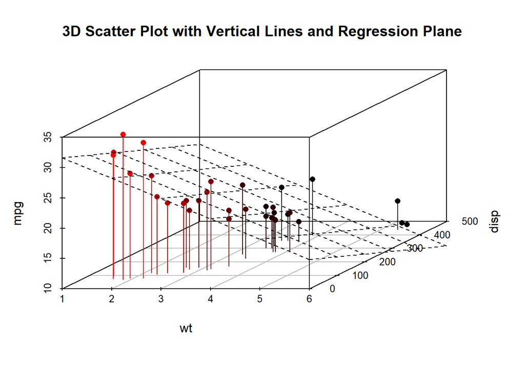

```r
attach(mtcars)
s3d <- scatterplot3d(
  wt,
  disp,
  mpg,
  pch = 16,
  highlight.3d = TRUE,
  type = "h",
  main = "3D Scatter Plot with Vertical Lines and Regression Plane"
)
fit <- lm(mpg ~ wt + disp)
s3d$plane3d(fit)
detach(mtcars)
```

# 3 相关图

```r
p_load(corrgram)
corrgram(
  mtcars,
  order = TRUE,
  lower.panel = panel.shade,
  upper.panel = panel.pie,
  text.panel = panel.txt,
  main = "Corrgram of mtcars intercorrelations"
)
```

[figure not shown]

```r
library(ggcorrplot)
data(mtcars)
corr <- round(cor(mtcars), 2)
corr
```

```
##        mpg   cyl  disp    hp  drat    wt  qsec    vs    am  gear  carb
## mpg   1.00 -0.85 -0.85 -0.78  0.68 -0.87  0.42  0.66  0.60  0.48 -0.55
## cyl  -0.85  1.00  0.90  0.83 -0.70  0.78 -0.59 -0.81 -0.52 -0.49  0.53
## disp -0.85  0.90  1.00  0.79 -0.71  0.89 -0.43 -0.71 -0.59 -0.56  0.39
## hp   -0.78  0.83  0.79  1.00 -0.45  0.66 -0.71 -0.72 -0.24 -0.13  0.75
## drat  0.68 -0.70 -0.71 -0.45  1.00 -0.71  0.09  0.44  0.71  0.70 -0.09
## wt   -0.87  0.78  0.89  0.66 -0.71  1.00 -0.17 -0.55 -0.69 -0.58  0.43
## qsec  0.42 -0.59 -0.43 -0.71  0.09 -0.17  1.00  0.74 -0.23 -0.21 -0.66
## vs    0.66 -0.81 -0.71 -0.72  0.44 -0.55  0.74  1.00  0.17  0.21 -0.57
## am    0.60 -0.52 -0.59 -0.24  0.71 -0.69 -0.23  0.17  1.00  0.79  0.06
## gear  0.48 -0.49 -0.56 -0.13  0.70 -0.58 -0.21  0.21  0.79  1.00  0.27
## carb -0.55  0.53  0.39  0.75 -0.09  0.43 -0.66 -0.57  0.06  0.27  1.00
```

```r
# Compute a matrix of correlation p-values
p.mat <- cor_pmat(mtcars)
p.mat
```

```
##               mpg          cyl         disp           hp         drat
## mpg  0.000000e+00 6.112687e-10 9.380327e-10 1.787835e-07 1.776240e-05
## cyl  6.112687e-10 0.000000e+00 1.802838e-12 3.477861e-09 8.244636e-06
## disp 9.380327e-10 1.802838e-12 0.000000e+00 7.142679e-08 5.282022e-06
## hp   1.787835e-07 3.477861e-09 7.142679e-08 0.000000e+00 9.988772e-03
## drat 1.776240e-05 8.244636e-06 5.282022e-06 9.988772e-03 0.000000e+00
## wt   1.293959e-10 1.217567e-07 1.222320e-11 4.145827e-05 4.784260e-06
## qsec 1.708199e-02 3.660533e-04 1.314404e-02 5.766253e-06 6.195826e-01
## vs   3.415937e-05 1.843018e-08 5.235012e-06 2.940896e-06 1.167553e-02
## am   2.850207e-04 2.151207e-03 3.662114e-04 1.798309e-01 4.726790e-06
## gear 5.400948e-03 4.173297e-03 9.635921e-04 4.930119e-01 8.360110e-06
## carb 1.084446e-03 1.942340e-03 2.526789e-02 7.827810e-07 6.211834e-01
##                wt         qsec           vs           am         gear
## mpg  1.293959e-10 1.708199e-02 3.415937e-05 2.850207e-04 5.400948e-03
## cyl  1.217567e-07 3.660533e-04 1.843018e-08 2.151207e-03 4.173297e-03
## disp 1.222320e-11 1.314404e-02 5.235012e-06 3.662114e-04 9.635921e-04
## hp   4.145827e-05 5.766253e-06 2.940896e-06 1.798309e-01 4.930119e-01
## drat 4.784260e-06 6.195826e-01 1.167553e-02 4.726790e-06 8.360110e-06
## wt   0.000000e+00 3.388683e-01 9.798492e-04 1.125440e-05 4.586601e-04
## qsec 3.388683e-01 0.000000e+00 1.029669e-06 2.056621e-01 2.425344e-01
## vs   9.798492e-04 1.029669e-06 0.000000e+00 3.570439e-01 2.579439e-01
## am   1.125440e-05 2.056621e-01 3.570439e-01 0.000000e+00 5.834043e-08
## gear 4.586601e-04 2.425344e-01 2.579439e-01 5.834043e-08 0.000000e+00
## carb 1.463861e-02 4.536949e-05 6.670496e-04 7.544526e-01 1.290291e-01
##              carb
## mpg  1.084446e-03
## cyl  1.942340e-03
## disp 2.526789e-02
## hp   7.827810e-07
## drat 6.211834e-01
## wt   1.463861e-02
## qsec 4.536949e-05
## vs   6.670496e-04
## am   7.544526e-01
## gear 1.290291e-01
## carb 0.000000e+00
```

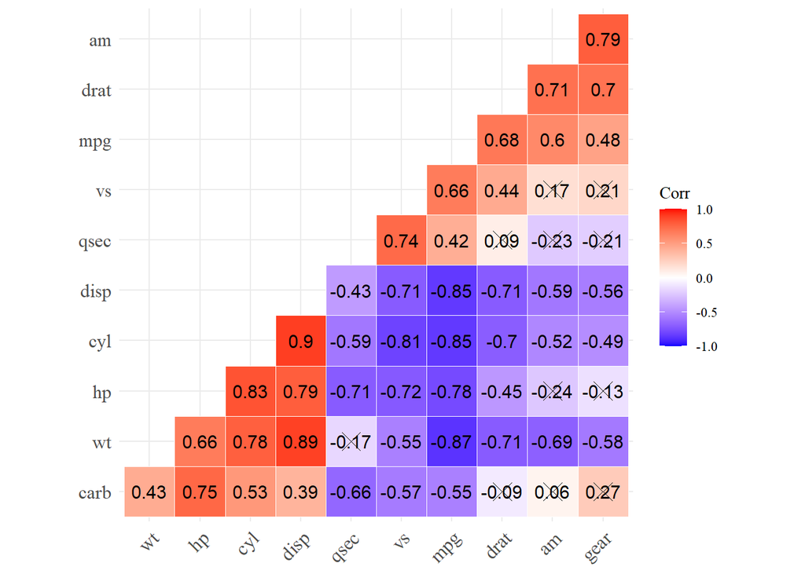

```r
ggcorrplot::ggcorrplot(corr,
                       hc.order = TRUE,
                       outline.color = "white",
                       lab = TRUE,
                       p.mat = p.mat,type = "lower") +
  theme(text = element_text(family = enfont))
```

# 4 马赛克图

```r
ftable(Titanic)
```

```
##                    Survived  No Yes
## Class Sex    Age
## 1st   Male   Child            0   5
##              Adult          118  57
##       Female Child            0   1
##              Adult            4 140
## 2nd   Male   Child            0  11
##              Adult          154  14
##       Female Child            0  13
##              Adult           13  80
## 3rd   Male   Child           35  13
##              Adult          387  75
##       Female Child           17  14
##              Adult           89  76
## Crew  Male   Child            0   0
##              Adult          670 192
##       Female Child            0   0
##              Adult            3  20
```

添加选项`shade=TRUE`将根据拟合模型的皮尔逊残差值对图形上色，添加选项`legend=TRUE`将展示残差的图例。

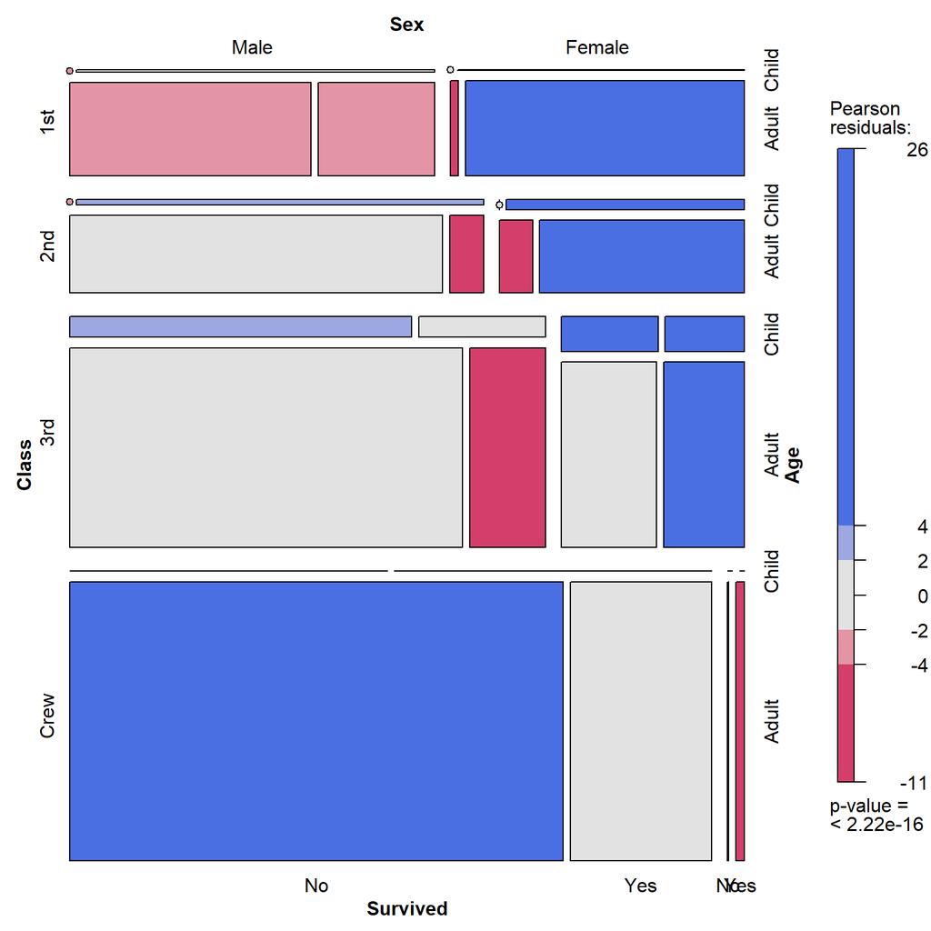

```r
p_load(vcd)
vcd::mosaic(Titanic,shade = TRUE,legend = TRUE)
```

- 1. 从船员到头等舱，存活率陡然提高；
- 2. 大部分孩子都处在三等舱和二等舱中；
- 3. 在头等舱中的大部分女性都存活了下来，而三等舱中仅有一半女性存活；
- 4. 船员中女性很少，导致该组的Survived标签重叠（图底部的No和Yes）。 继续观察，你将发现更多有趣的信息。关注矩形的相对宽度和高度，你还能发现那晚其他什么秘密吗？

这样，**图形的定制**（第3章）、**单变量分布的展示**（第6章）、**回归模型的探究**（第8章）和**组间差异的可视化**（第9章）等方法，就构成了你的可视化数据和提取数据信息的完备工具箱。

在后续各章中，通过学习其他专业化技术，比如**潜变量模型图形绘制**（第14章）、**时间序列**（第15章）、**聚类数据**（第16章）和**单条件或多条件变量图形的创建技巧**（第18章），你还可以大幅度提升自己的绘图能力。

下一章，我们将探究**重抽样**和**自助法**。它们都是计算机密集型方法，为你提供了一种分析数据的全新而独特的视角。